# Week 1 Notes

## Notes for Intoductory Class - Week 1

#### Personal background on statistics and this book

- little background in statistics
- frustrated with PCMs and the lack of flexibility
- Didn’t realize all the options out there!

#### Multilevel modeling

- Allows us to create generative models of our data, or the joint probabilities of our variables
- There are natural structures in our data that can’t be ignored, like taking the mean of a species

#### Bayesian Approach

- Offers the most logical and practical way to model our data
- Conducive to regularization, missing data, etc,
- Probabilities offer an intuitive way to explain and understand our systems
- There is a principled workflow
- Many tools are tighly integrated with other data science tools for easy visualization, data wrangling, etc.

#### This Seminar Course

- In addition to the text, using the 2022 lectures and the rethinking in brms book
- Newest version of the course focus heavily on scientific models, causal inference, and DAGs. New to me!
- Explain expectations -> Mark?
- Principles Bayesian Workflow: Scientific Model -> Statistical Model -> Prior Predictive Simulation -> Model Fitting -> Predictive Accuracy/Model Comparison -> Posterior Predictive Simulation -> Data Visualization and Reporting

#### Tools

- Rethinking package, and brms package. If you are not wedded to base R, I strongly suggest learning the tidyverse!!!!!
- RStudio, RMarkdown, knitting
- Scripting, Software engineering by amateurs. Important to document work, and make it reproducible! And Keep track of it! RMarkdown makes this really easy.

```r
pacman::p_load(tidyverse, brms)
```

```r
m1 <- brm(mpg ~ hp, data = mtcars, refresh = 0)
loo(m1)
```

```
Computed from 4000 by 32 log-likelihood matrix
```

|  | Estimate | SE |
| --- | --- | --- |
| elpd_loo | -91.6 | 4.7 |
| p_loo | 3.9 | 1.7 |
| looic | 183.2 | 9.3 |

```
------
Monte Carlo SE of elpd_loo is NA.

Pareto k diagnostic values:
                         Count Pct.    Min. n_eff
(-Inf, 0.5]   (good)     31    96.9%   1236
 (0.5, 0.7]   (ok)        0     0.0%   <NA>
   (0.7, 1]   (bad)       1     3.1%   79
   (1, Inf)   (very bad)  0     0.0%   <NA>
See help('pareto-k-diagnostic') for details.
```

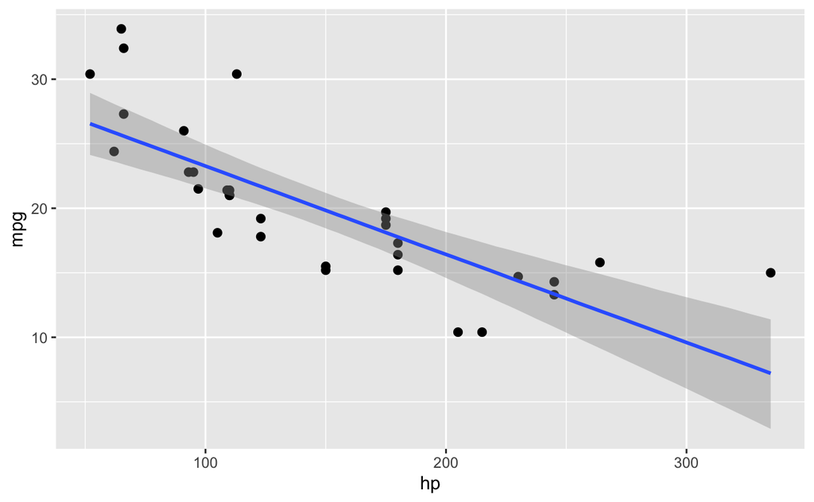

```r
plot(conditional_effects(m1), points = T)
```

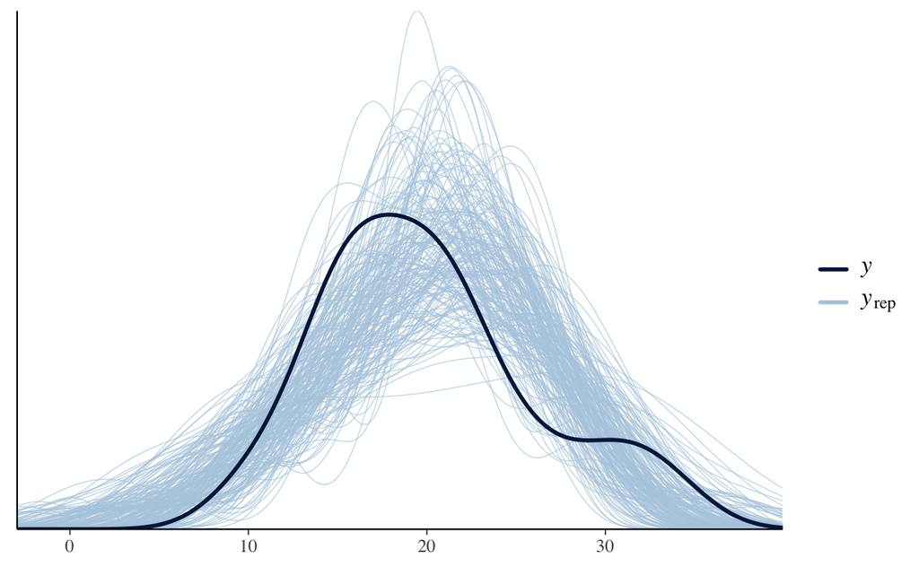

```r
pp_check(m1, ndraws = 200)
```